# Question 2

# Introduction

For this question my goal is to prove to my friend that the weather in the UK is terrible.

# Analysis

To conduct my analysis I must first import my data files.

Ok so first I want to plot a temperature graph showing the mean temperature for each month for both london and the midlands datasets. I will make a function which does this and therefore I can replicate the process with other weather elements. I’m interested in convincing you not to move there, therefore I am only concerned with assessing the weather since the turn of the 21st century.

Plotting a bargraph of the average temperature, sunshine, rain and cloud cover in London per month.

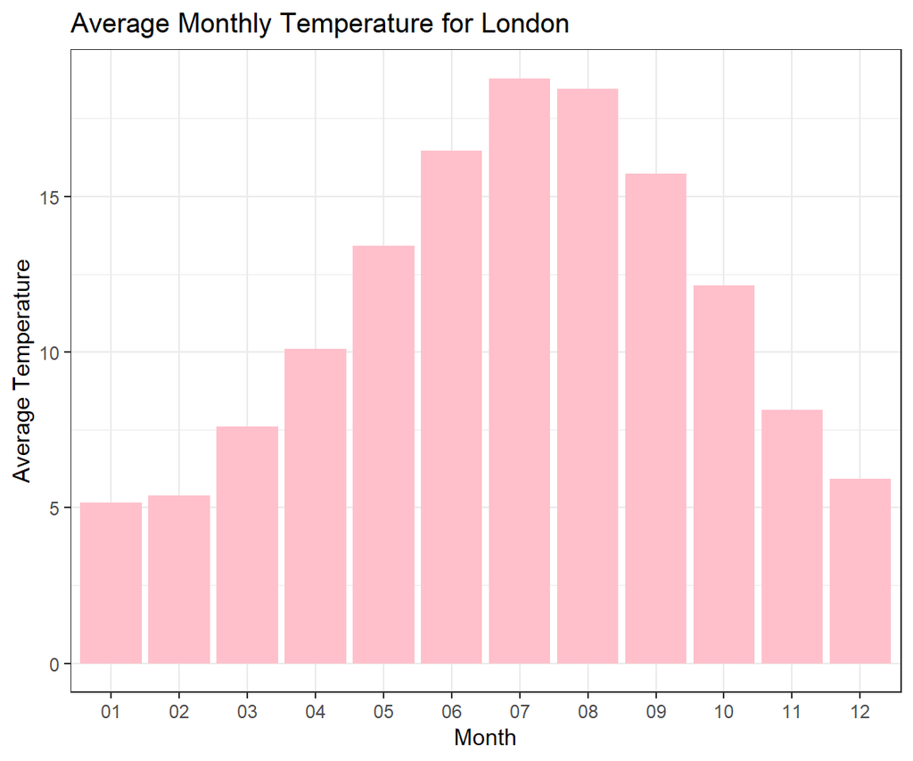

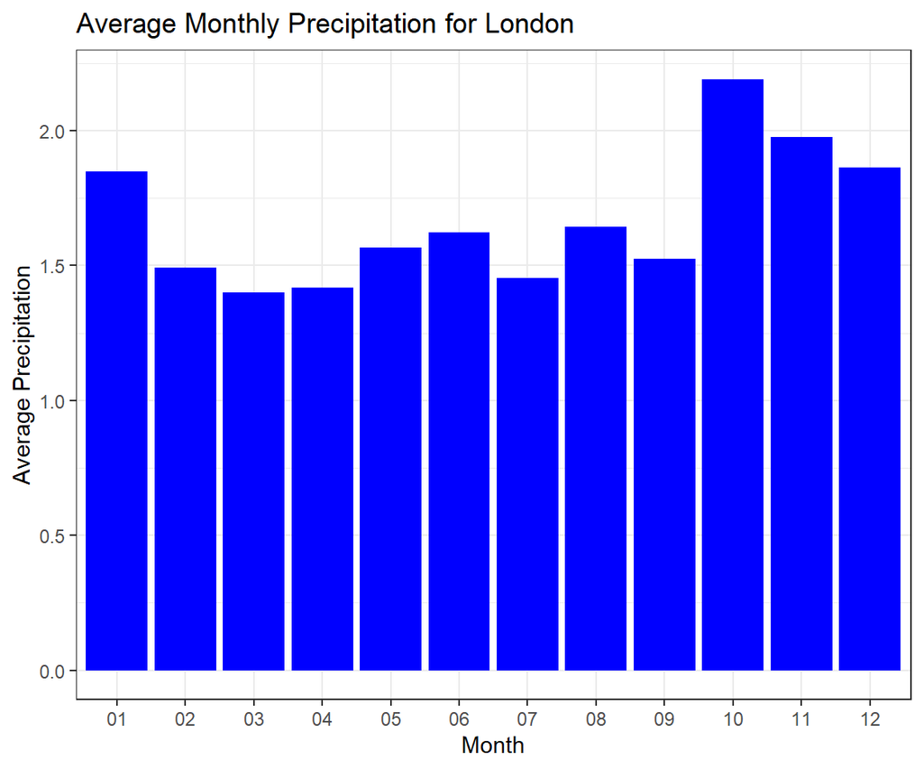

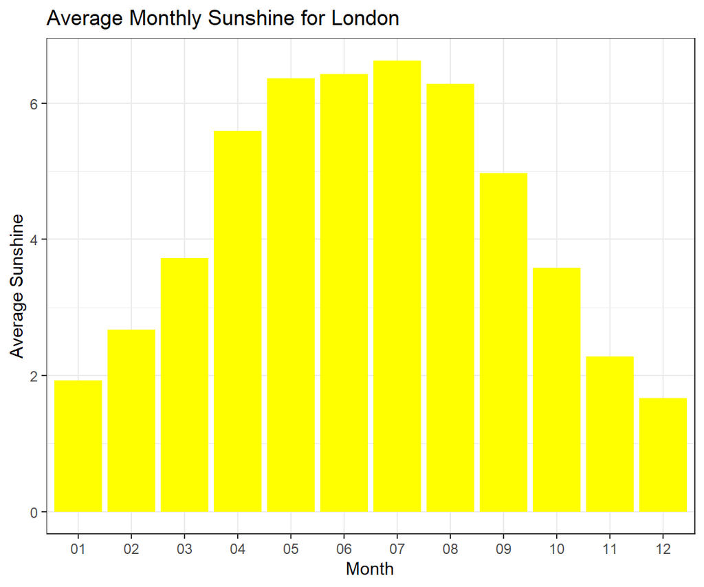

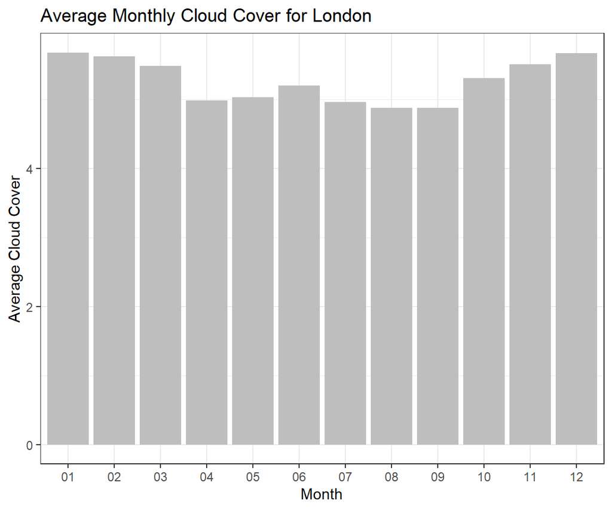

This measures the average for each month over a 20 year period and as can be seen the weather in London is pretty miserable. In their best months they only get 6 hours of sun on average a day, even though it is daytime for over 16 hours in those months. They get constant rain and cloud cover throughout the year and their average temperature doesn’t even get above 20 in their best months. But you want to live in the mid parts of england so lets see how these stats look compared to London.

Now we must import the data for the midlands in the UK and look at the monthly weather here.

Now we transfrom the data.

Ok so the only values we have are for temperature and precipitation. Once again we’re looking at the average temperature for each month over a 20 year period. However for precipitation the data shows the amount of rain on the most rainy day in the month. These values are then average over 20 years.

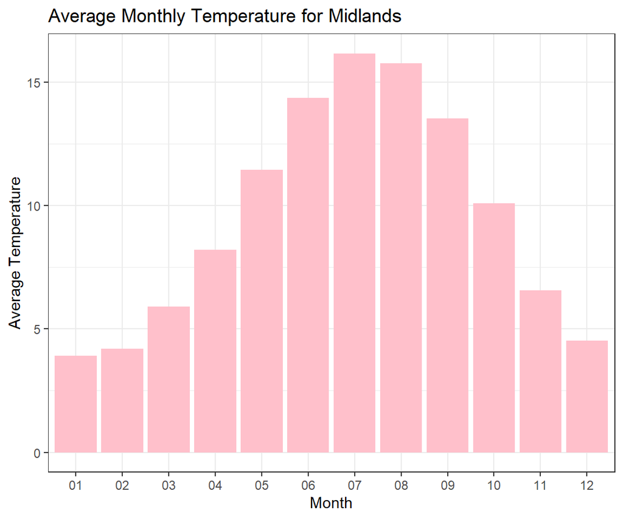

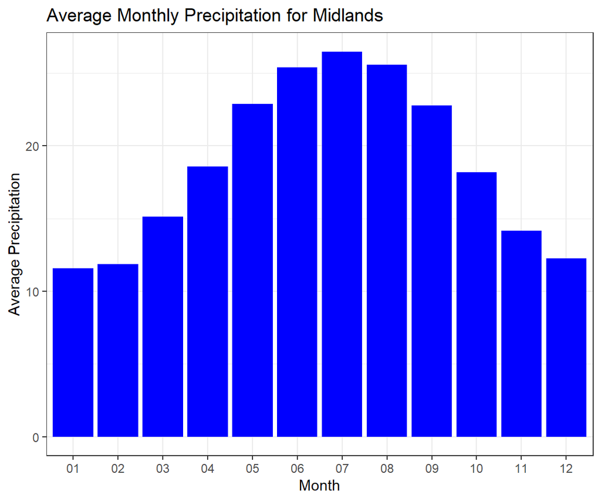